# Weekly update for May 29

Heike Hofmann

## Show and Tell May 29

## Bullet matching (Heike)

- scans from Sensofar (Bill Henderson) of bullets by Phoenix PD: 8 barrels (2 shots), 2 unknown bullets
- total of 108 lands (each file ~133 MB)
- available from `/myfiles/las/research/csafe/bullet-scans/Phoenix Test/`

## Changes to bulletr

- changes to parameter settings in `bulletr` (`groove_cutoff`, `smooth_factor` in `get_groove` both depend on resolution)
- `get_groove` has now parameter `method` - just hook any alternative method in here.
- currently available methods are `rollapply` (Eric’s) and `middle` (takes middle 75 percent of a land)

## Results

- feature set for Phoenix PD bullet lands are a bit strange
- next week: investigate feature set

## Chumbley Score

- Chumbley score is non-parametric test based on multiple correlation values extracted from striation marks of two lands (Chumbley et al 2010)

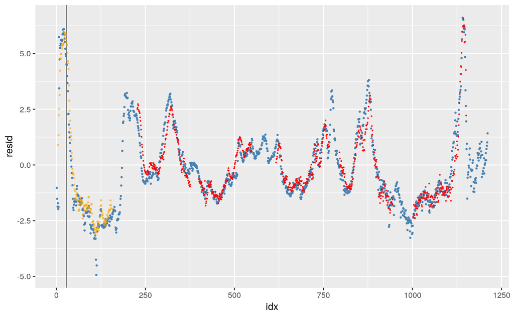

## Chumbley score

```r
# aligned correlation scores
ctest[[3]]
```

```
## [1] 0.9188150 0.9362759 0.8998899 0.9380428 0.9556710
```

```r
# random correlation scores
ctest[[4]]
```

```
## [1]  0.20041773  0.82400654 -0.13149010  0.08690511  0.60409433
```

```r
# results from Mann-Whitney U test
ctest$test
```

```
##
##  Wilcoxon rank sum test
##
## data:  cor_matched and cor_random
## W = 25, p-value = 0.003968
## alternative hypothesis: true location shift is greater than 0
```

## Chumbley on Phoenix PD (orange is known match)

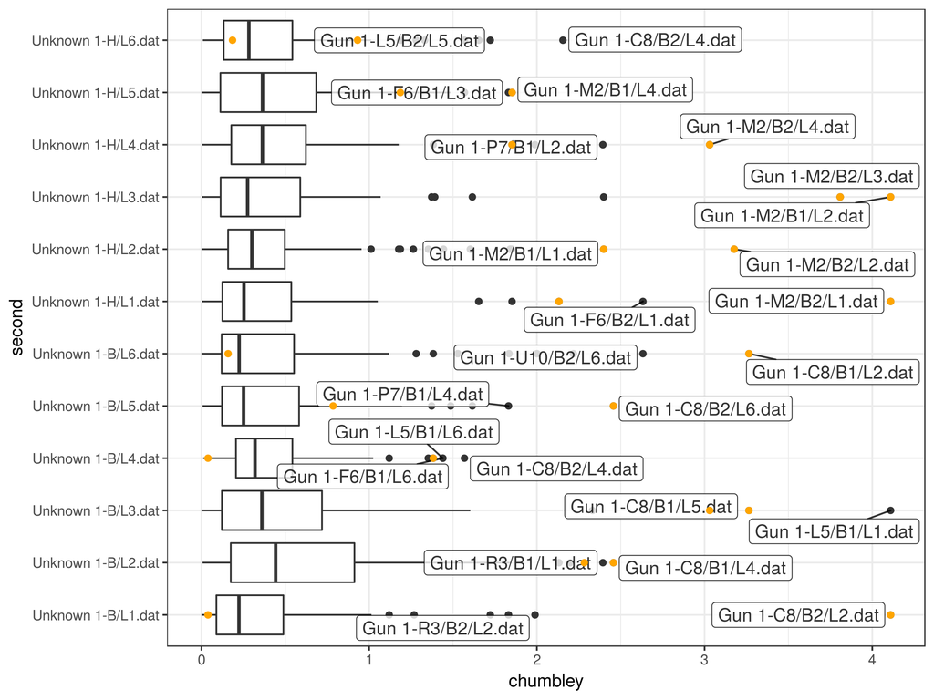

## Chumbley on Phoenix PD, again

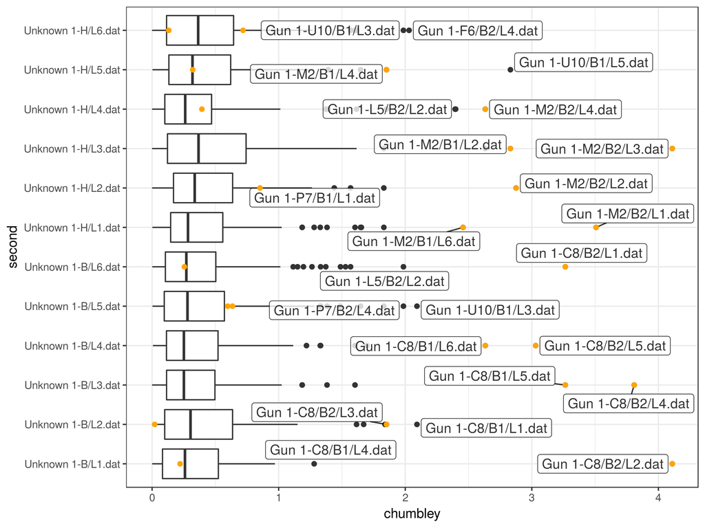

## Chumbley score

- impact of parameters (window width, number of replicates) on test result?
- variability of results?

## More on Grooves (Kiegan and Ulrike)

- working with development version of `bulletr`, looking at `get_grooves`
- making sure we understand what the current code is doing
- now with updates for parameter `method`, we will start looking at new methods to add
- also adding a `get_grooves_test` that includes plot of smoothed crosscut
- alternatively, an option in the function to output the smoothed plot

## Optional smoothed grooves output

- thinking this could be added as an option depending on the method
- allows us to check to make sure the image is “smooth enough”
- if it is misidentifying, this gives a check for whether its because there is a bump before the true peak
- works in my clone of the dev version of bulletr

## Original plot from get_grooves

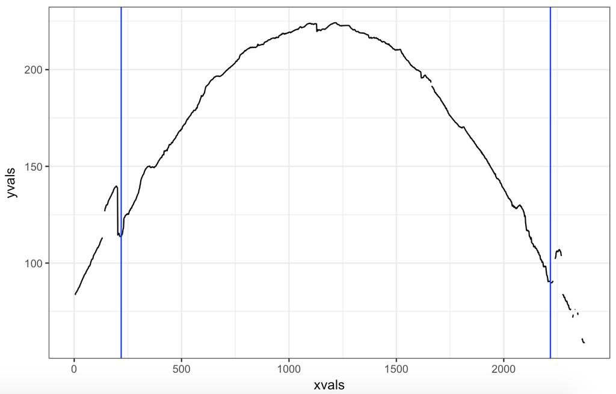

## New smoothed option for get_grooves

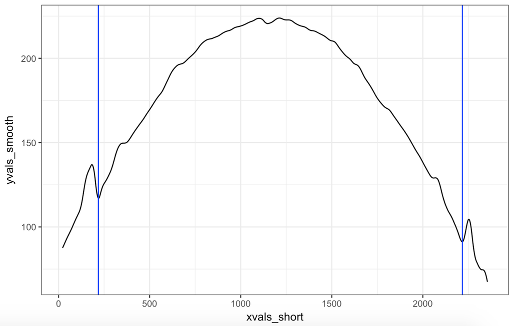

## Handwriting Analysis (Amy)

Two objectives - Begin with human QD examiners specifying characteristics - Automated determination of characteristics

## Begin with human QD examiners specifying characteristics

- Sargur N. Srihari, University of Buffalo
- CEDAR-FOX software
- CEDAR dataset
- CEDAR letter
- over 1,500 individuals wrote the letter three times each
- representative of the United States population

## CEDAR letter

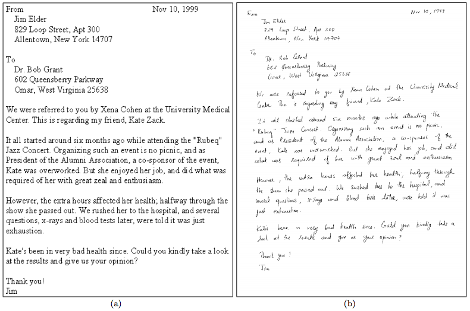

## CEDAR-FOX

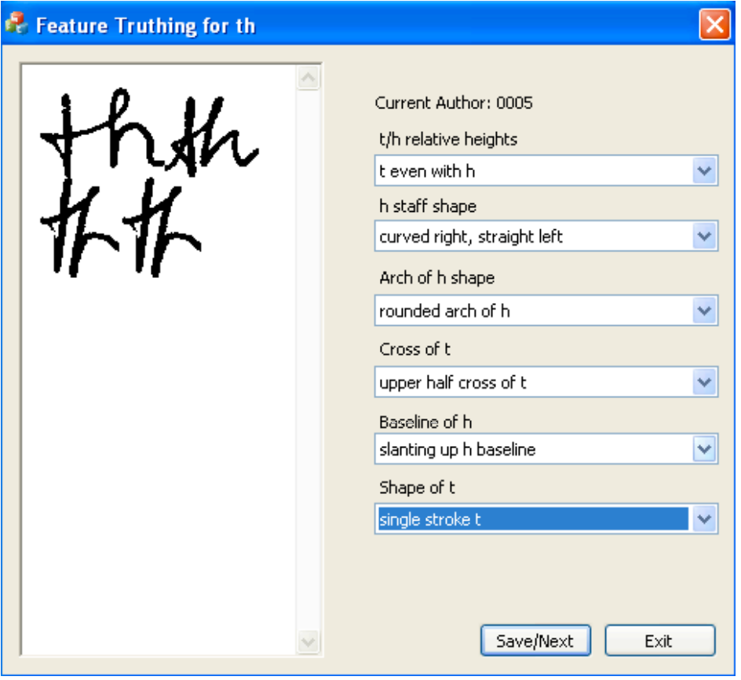

## CEDAR-FOX

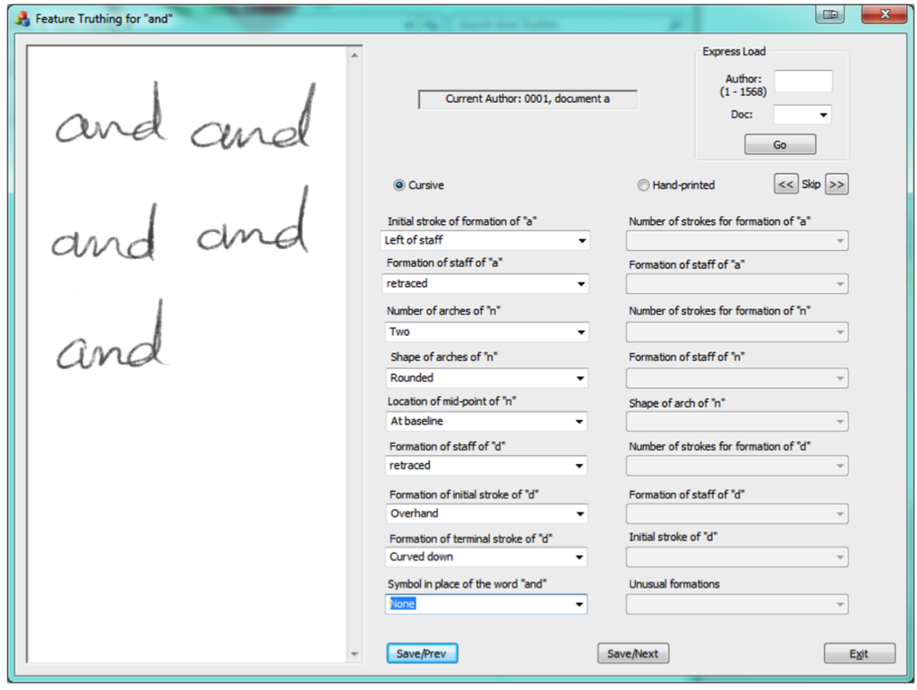

## Statistical Models and Inference

- Problem complexity
- Bayesian Networks
- Markov Networks
- Probability of Evidence

## Automated determination of characteristics

- Christopher Saunders, PhD
- FLASH ID software (proprietary)
- “… the careful reader should be able to implement a similar system based on the information in this article.”
- Data: modified London Letter (FBI)
- Skeleton of the writing, 1 pixel in width
- Identify nodes and edges
- Topology and Geometry

## Graphemes

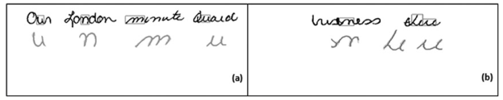

## Shoeprints

- Guillermo and Martin have scans of shoesoles
- Go [here](https://iastate.box.com/s/jdtxxj0ox26fc65sfqzbmvnf594f7hrr) to access them
- There are (5 types of shoe)x(2 models with the same outsole pattern)x(left and right feet)x(5 replicates per shoe) = 100 scans.
- We want to ultimately determine whether it is possible to determine whether a shoeprint was generated with a given shoe.
- The parameters of an affine transformation will be find by manually selecting two points on each scan. Code will be available for you in the future (as an R package).